# Vaccination model with waning

Irena Papst

19 Nov 2021

Here we demonstrate an implementation of waning (vaccine-derived) immunity in the `McMasterPandemic` model with two-dose vaccination.

The gist is that there is an additional vaccination layer (after the “two-dose protection” layer) that is for individuals whose two-dose immunity has waned. People can enter the waned layer from the two-dose protection layer in two ways:

- $S_{\rm two dose} \rightarrow S_{\rm waned}$, where $S$ = susceptible individuals, i.e. those that have never had a SARS-CoV-2 infection
- $R_{\rm two dose} \rightarrow R_{\rm waned}$, where $R$ = recovered, i.e. those that have at some point in the past had a natural infection.

We allow individuals in the waned layer to be subject to a different vaccine efficacy, probability of asymptomatic infection, and probability of mild (vs severe) infection than in other vaccination layers.

## Model specification

To specify the two-dose model with waning vaccine-derived immunity, we proceed in a (hopefully) familiar way. We start with base model parameters,

```r
base_params <- read_params("PHAC.csv")
```

which we can expand them with vaccination:

```r
vax_params <- expand_params_vax(
  params = base_params,
  model_type = "twodosewane",
  vax_wane_time = 180,
  vax_wane_time_R = Inf, ## to shut the associated flow off, since it's computed as 1/vax_wane_time_R = 1/Inf = 0
  vax_efficacy_wane = 0.7,
  vax_alpha_wane = 0.5,
  vax_mu_wane = 1
)
```

```r
knitr::kable(describe_params(vax_params) %>% filter(grepl("wane", symbol)))
```

| symbol | value | meaning |
| --- | --- | --- |
| vax_efficacy_wane | 0.7 | Infection-blocking vaccine efficacy for individuals whose two-dose vaccination protection has waned |
| vax_alpha_wane | 0.5 | Proportion of infections that are asymptomatic (vs symptomatic) in individuals whose two-dose vaccination protection has waned |
| vax_mu_wane | 1 | Proportion of infections that are mild (vs severe) in individuals whose two-dose vaccination protection has waned |
| vax_wane_rate | 0.00556 | Rate at which an individual’s two-dose immunity wanes, for an individual who has never been infected (in units of 1/days) |
| vax_wane_rate_R | 0 | Rate at which an individual’s two-dose immunity wanes, for an individual who has never been infected (in units of 1/days) |

(Much like the vaccine response time parameters from the basic vaccination model (`vax_response_time` and `vax_response_time_R`), the new parameters related to waning rates, `vax_wane_time` `vax_wane_time_R`, get specified in terms of the average number of days to a given event, and then converted into a rate by taking the reciprocal. So, for the waning model, `vax_wane_time` gets specified by the user, but `vax_wane_rate` gets stored in the parameter list.)

## Example simulation with the waning model

We simulate an outbreak over two years.

```r
start_date <- "2020-03-20"
end_date <- "2022-03-20"
```

We use the default parameters in `PHAC.csv` for SARS-CoV-2 (with a population size of 1,000,000), and the default vaccination parameters assumed by `expand_params_vax()`, with two adjustments:

1. we will bring bring the transmission rate down to a very low rate of 0.3 transmissions per susceptible per day at the start of the simulation;
2. we will vaccinate at a constant rate of 10,000 doses per day (all first doses to start).

This simulates a scenario where vaccines are deployed at the start of an outbreak, though strict non-pharmaceutical interventions are also initially in effect, keeping transmission low during the vaccine roll-out.

```r
## slow down transmission and vax from default
vax_params <- update(vax_params,
       beta0 = 0.3,
       vax_doses_per_day = 1e4)
```

We also make two parameter adjustments part-way through the simulation, to simulate changing conditions:

```r
## start administering second doses 8 weeks after start date
params_timevar <- data.frame(
  Date = c(as.Date(start_date) + 8*7, as.Date("2020-10-01")),
  Symbol = c("vax_prop_first_dose", "beta0"),
  Value = c(0.7, 2),
  Type = rep("rel_orig", 2)
)
```

```r
res <- run_sim(
  params = vax_params,
  start_date = start_date,
  end_date = end_date,
  params_timevar = params_timevar,
  condense_args = list(keep_all = TRUE)
)
```

This simulation results in the following predicted count of daily infection reports:

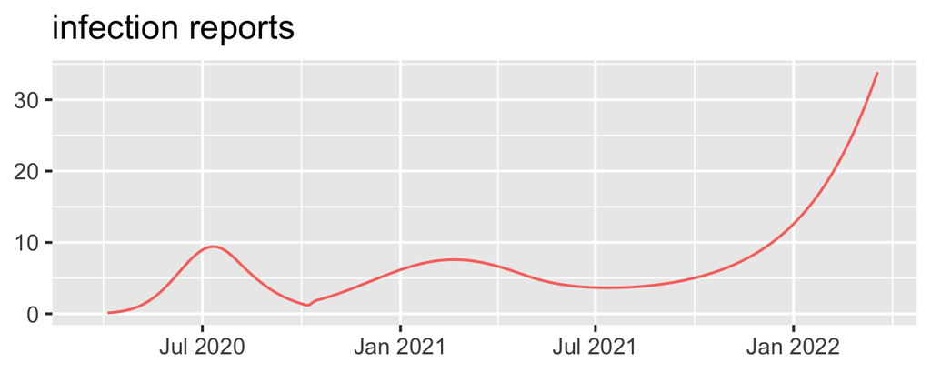

```r
plot_total(res)
```

The simulation results in two distinct, small waves, followed by a much larger uptick towards the end of the simulation. We can see which groups are driving each wave if we stratify the simulation results by vaccination layer. The strata are:

- `unvax`: unvaccinated individuals
- `vaxdose1`: individuals who have received one dose but have not yet undergone the protective immune response
- `vaxprotect1`: individuals that are protected by one dose of the vaccine
- `vaxdose2`: individuals who have received two doses but have not yet undergone the protective immune response to the second dose of vaccine
- `vaxprotect2`: individuals that are protected by two doses of the vaccine
- `vaxwane2`: individuals who have received two doses of the vaccine, but their vaccine-derived immunity has waned

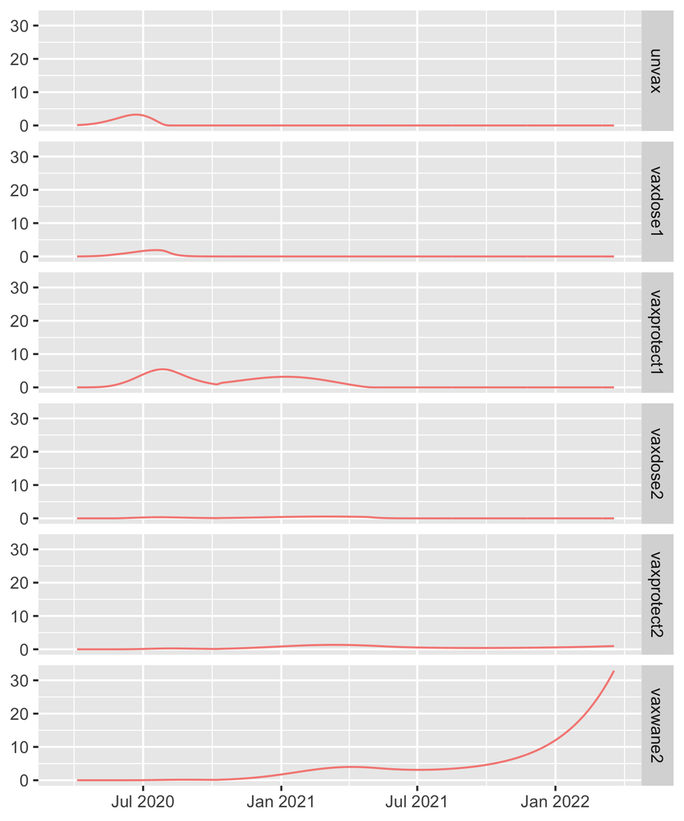

```r
plot_stratified(res)
```

## Variants of concern

The two-dose wane model has also been integrated with the variant expansion as well:

```r
variant_params <- expand_params_variant(
  params = vax_params,
  variant_prop = 1,
  variant_vax_efficacy_wane = 0.6
)
```

One additional parameter must be specified:

```r
knitr::kable(describe_params(variant_params) %>% filter(grepl("variant.*wane", symbol)))
```

| symbol | value | meaning |
| --- | --- | --- |
| variant_vax_efficacy_wane | 0.6 | Vaccine efficacy against variant for individuals whose two-dose protection has waned (only used in vaxified model) |

Here, we assume that a new variant reduces infection-blocking vaccine efficacy to 60%. We also assume that the variant is 50% more transmissible, and gets introduced into 1 Jul 2021, at which point it (suddenly) represents 50% of all infections going forward.

```r
params_timevar <- rbind(
  params_timevar,
  data.frame(
    Date = c(as.Date(start_date), as.Date("2021-07-01")),
    Symbol = rep("variant_prop", 2),
    Value = c(0, 0.5),
    Type = rep("rel_orig", 2)
  ))
```

Running the simulation…

```r
res <- run_sim(
  params = variant_params,
  start_date = start_date,
  end_date = end_date,
  params_timevar = params_timevar,
  condense_args = list(keep_all = TRUE)
)
```

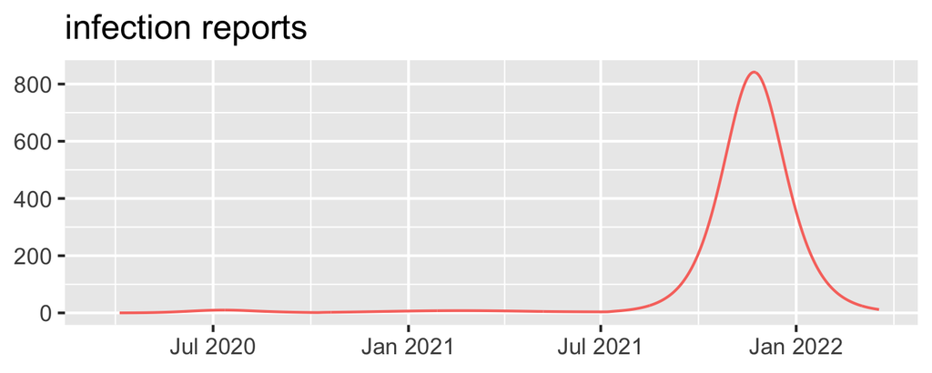

```r
plot_total(res)
```

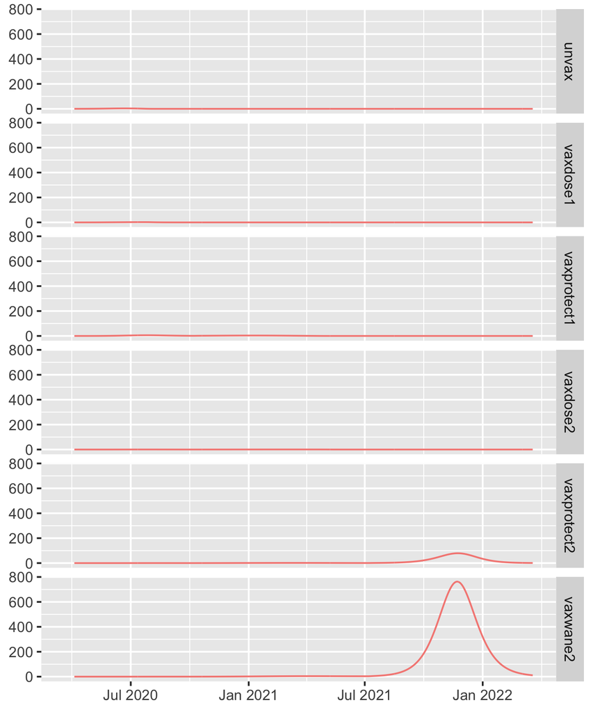

```r
plot_stratified(res)
```

The late introduction of the variant has a sizeable effect on breakthrough cases, though eventually the epidemic turns over thanks to susceptible depletion (mostly of individuals whose two-dose immunity has waned slightly).